# 2-Limpieza y Preparación de Datos

Felipe Ortega

27 de mayo de 2021

# 1 Introducción

En este tema describiremos las tareas más habituales de limpieza y preparación de datos, creando **variables de entrada** para nuestros modelos/algoritmos. En el campo del aprendizaje máquina, a las variables de entrada se las denomina **features** (*características*) y este proceso se suele conocer como *feature engineering* (dando cuenta de la naturaleza práctica y empírica de este proceso, en muchos casos).

Entre otros, abordaremos los siguientes aspectos principales:

1. Tratamiento de variables cuantitativas.
2. Tratamiento de variables categóricas, incluyendo codificación.
3. Detección de datos faltantes (*missing data*) e imputación de datos.
4. Comprobación de reglas en datos (*quality check*).
5. Combinación de variables (reducción de dimensionalidad).
6. Otros métodos de construcción de variables.
7. Algoritmos para *feature engineering*.

## 1.1 Conjuntos de datos

A continuación, se presentan los principales conjuntos de datos que vamos a utilizar.

### 1.1.1 Datos de paquetes R

| Items | Features |
| --- | --- |
| dplyr::iris | Clásico dataset con información botánica sobre tres especies de flores iris. |
| `ISLR::Auto` | Consumo de combustible, potencia del motor e información adicional sobre diferentes modelos de coches. |
| `DMwR2::algae` | Propiedades químicas extraídas de muestras de agua procedentes de distintos ríos europeos, junto a datos sobre niveles de concentración de 7 tipos de algas potencialmente dañinas. Datos recabados en l… |
| `car::UN` | Datos socioeconómicos de 213 lugares, la mayoría miembros de la ONU. |
| `faraway::pima` | Datos sobre un estudio elaborado por el Instituto Nacional de Diabetes, Enfermedades DIgestivas y de Riñón (EE.UU.), sobre 768 mujeres adultas de la etnia india Pima, cerca de Phoenix. |
| `mlbench::Sonar` | Datos de un estudio de Gorman y Sejnowsk (1988), para un benchmark de modelos de predicción con redes neuronales. El modelo debe clasificar señales sonar rebotadas por un objeto metálico cilíndrico de… |

### 1.1.2 Datos de otras fuentes

| Items | Features |
| --- | --- |
| `AcmeTelephoneABT.csv` | Datos sintéticos sobre un caso de estudio hipotético, para predecir la fuga de clientes de una compañía telefónica (Kelleher, Namee, and D’Arcy 2015) |

## 1.2 Paquetes R

Estos son los paquetes de R utilizados en este documento.

```r
library(dplyr)
library(tidyr)
library(ggplot2)
library(egg)
library(GGally)

library(ISLR)
library(car)
library(DMwR2)
library(faraway)
library(mlbench)

library(knitr)
library(kableExtra)
library(htmltools)
library(bsplus)
library(RColorBrewer)
```

# 2 Análisis exploratorio de los datos (EDA)

El primer paso siempre debe consistir en efectuar un análisis exploratorio de los datos, para empezar a detectar posibles problemas.

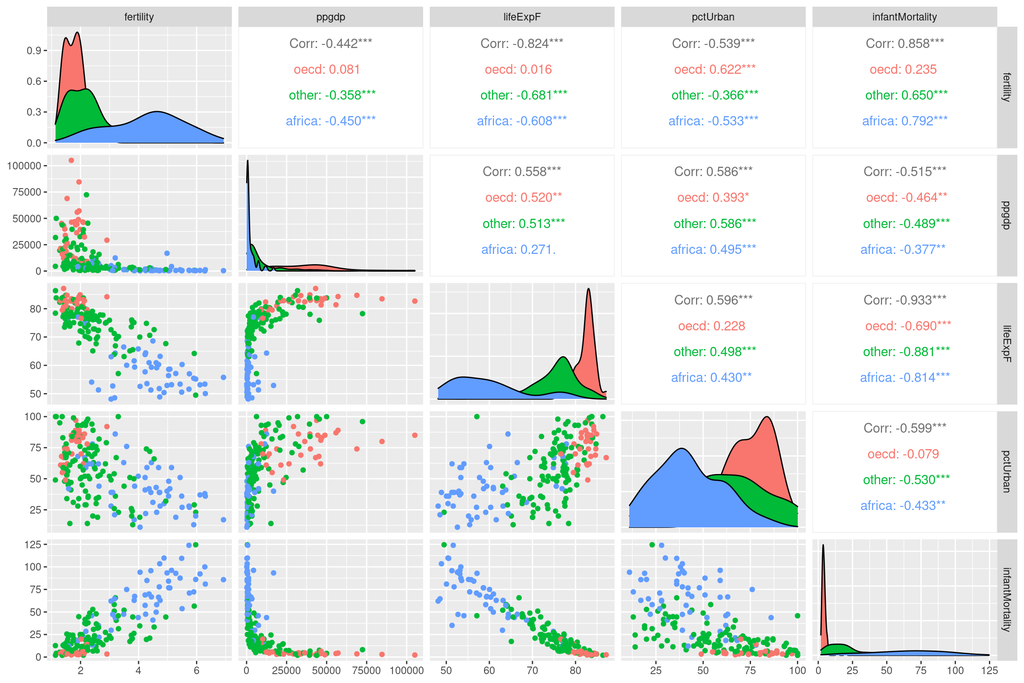

```r
UN %>% select(2:7) %>%
  na.omit() %>%
  ggpairs(columns = 2:6, ggplot2::aes(colour=group))
```

# 3 Transformación de variables cuantitativas

El primer conjunto de operaciones comprende la transformación de valores de variables cuantitativas. Con frecuencia, el objetivo de esta tarea es obtener una variable cuya distribución de valores sea:

- Más simétrica y con menor dispersión que la original.
- Más semejante a una distribución normal (e.g. para algunos modelos lineales).
- Restringida en un intervalo de valores (e.g. $[0, 1]$).

La forma más sencilla de detectar que alguna de nuestras variables necesita ser transformada es representar un gráfico que muestre la distribución de valores de la variable. Por ejemplo, un histograma o un diagrama de densidad de probabilidad (o ambos).

## 3.1 Transformaciones para igualar dispersión

En el caso de la variable `ppgdp` del dataset `UN`, podemos ver que sus valores para t odos los grupos están muy sesgados. Sería conveniente transformarla para que la distribución de valores fuese más homogénea. Este resultado se consigue aplicando una **transformación logarítmica**.

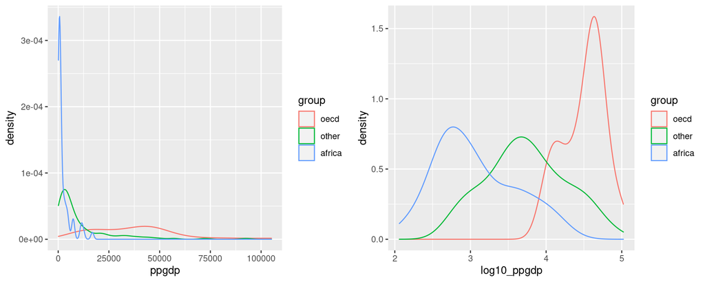

Figure 3.1: Comparativa de función de densidad de probabilidad de la variable `ppgdp` del dataset `UN` antes y después de aplicar la transformación logarítmica.

```r
p1 <- UN %>% select(group, ppgdp) %>%
  na.omit() %>%
  ggplot(aes(x=ppgdp, colour=group)) +
    geom_density()

p2 <- UN %>% mutate(log10_ppgdp = log10(ppgdp)) %>%
  select(group, log10_ppgdp) %>%
  na.omit() %>%
  ggplot(aes(x=log10_ppgdp, colour=group)) +
    geom_density()

grid.arrange(p1, p2, nrow = 1)
```

El uso de los logaritmos tiene su propia recomendación en preparación de datos (Fox and Weisberg 2011): *“si la variable es estrictamente positiva, no tiene un límite superior para sus valores, y su rango abarca dos o más órdenes de magnitud (potencias de 10), entonces la transformación logarítmica suele ser útil.”*. A la inversa, cuando la variable tiene un rango de valores pequeño (menor de un orden de magnitud), el logaritmo o cualquier otra transformación simple no ayudará mucho.

La versión general de esta transformación son las **transformaciones de escala-potencia** (*scaled-power transformations*), también denominadas **transformaciones de Box-Cox** por haber sido presentadas por primera vez en un artículo de estos autores en 1964.

$$x^{(\lambda)} =
\begin{cases}
\frac{x^\lambda - 1}{\lambda} & \text{when $\lambda \neq 0$}\\
log_e(x) & \text{when $\lambda = 0$}
\end{cases}$$

La función `car::symbox(...)` permite probar varias combinaciones típicas del parámetro $\lambda$, para comprobar con cuál de ellas obtenemos una distribución más simétrica de valores.

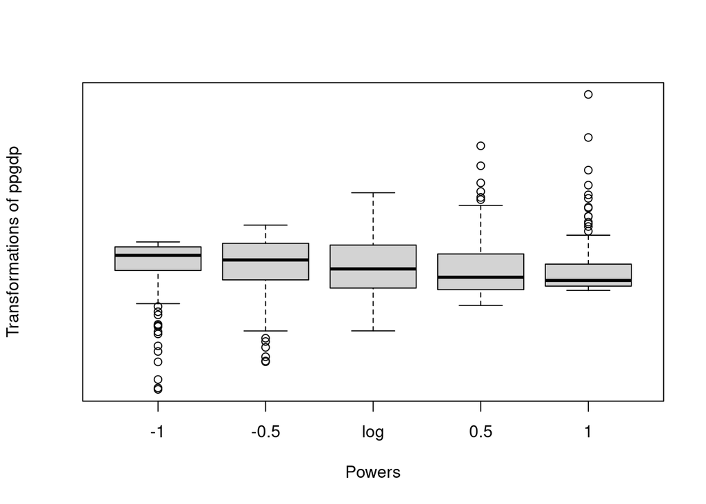

Figure 3.2: Gráfica generada por la función `car::symbox` para comprobación de la transformación más adecuada para igualar dispersión.

```r
UN %>% select(group, ppgdp) %>%
  na.omit() %>%
  filter(group == 'other') %>%
  symbox(~ ppgdp, data = .)
```

En el caso de que queramos comprobar qué transformación es más adecuada cuando la variable puede depender de otro valor categórico, la función `car::spreadLevelPlot(...)` es muy conveniente. En este caso, se representa el logaritmo del IQR de la variable cuantitativa (dispersión) frente al logaritmo de la mediana en cada grupo (nivel). Debemos recordar que la variable cuantitativa debe ser estrictamente positiva. Para garantizar esto, podemos por ejemplo sumar a todos los valores una constante (*offset*), de forma que los llevemos todos al lado positivo de la escala. Esta operación no afecta para nada al cálculo del tipo de transformación a realizar (se traslada su posición, pero no las propiedades de dispersión de la distribución).

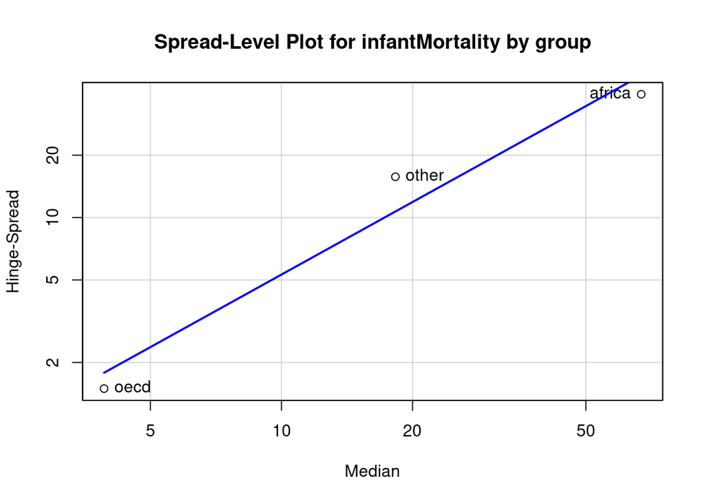

```
##        LowerHinge  Median UpperHinge Hinge-Spread
## oecd        3.346  3.9140     4.8415       1.4955
## other      10.534 18.2680    26.2690      15.7350
## africa     46.588 67.0175    85.9400      39.3520
##
## Suggested power transformation:  -0.1627873
```

```r
UN_splvplot <- UN %>% select(group, infantMortality) %>%
  na.omit()
  spreadLevelPlot(infantMortality ~ group, data = UN_splvplot)
```

Si hay una relación entre la dispersión y el nivel, como en este caso, se elige la transformación ajustando una recta a los puntos del gráfico. Si la pendiente de la recta es $b$, una posible transformación útil es la potencia $1-b$. En el caso de la variable `infantMortality`, el valor sugerido es $-0.163$, por lo que una aproximación usando la transformación logarítmica puede ser válida.

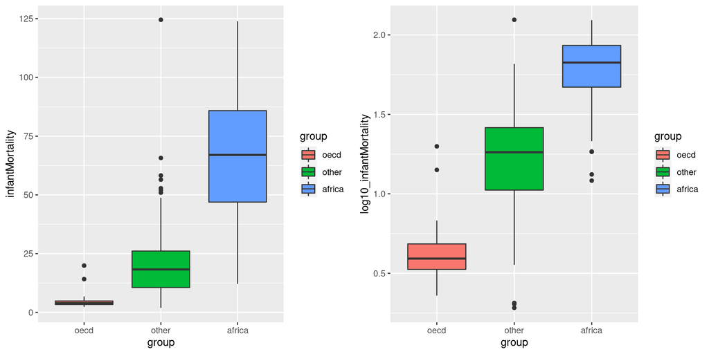

Figure 3.4: Efecto de la transformación logarítmica en la variable `infantMortality` del dataset `UN`.

```r
p1 <- UN %>% select(group, infantMortality) %>%
  na.omit() %>%
  ggplot(aes(x=group, y=infantMortality, fill=group)) +
  geom_boxplot()

p2 <- UN %>% mutate(log10_infantMortality = log10(infantMortality)) %>%
  select(group, log10_infantMortality) %>%
  na.omit() %>%
  ggplot(aes(x=group, y=log10_infantMortality, fill=group)) +
  geom_boxplot()

grid.arrange(p1, p2, nrow = 1)
```

En la siguiente Tabla se resumen algunas transformaciones alternativas que pueden resultar útiles.

| Transformación | Propiedades |
| --- | --- |
| Raíz cuadrada: $\sqrt{x}$ `sqrt(x)` | Suele ser útil cuando tratamos con conteos. Transforma una Poisson en una Normal. Es menos intensa que el logaritmo |
| Inversa: $1/x$ | Si la transformación logarítmica se queda “corta,” podemos probar con la inversa |
| Arcoseno: $sin^{-1}(x)$ | Útil para porcentajes y proporciones que no se distribuyen normalmente |

Por último, si la distribución presenta un importante **sesgo negativo**, es decir, la cola larga de valores está a la izquierda y no a la derecha del cuerpo principal, entonces la solución es *reflejar la distribución* en primer lugar, restando cada uno de los valores a una constante:

$$T_{especular}(x_{i}) = k-x_{i}, \; \text{donde } k = max(x_i) + 1.$$

Como hemos visto, al aplicar la transformación logarítmica sobre una variable de entrada y la salida podemos mejorar la resolución en ambos ejes de representación, con lo que la relación entre ambas es mucho más evidente. Ahora queda el problema de cómo deshacer la transformación, para poder presentar los resultados de un modelo en las mismas unidades que las variables originales.

Supongamos que hemos propuesto el siguiente modelo, una vez transformadas la variable de entrada y la de salida:

$$\log(\text{infantMortality}) = \beta_0 + \beta_1 \log(\text{ppgdp}) + \varepsilon,$$

siendo \(\varepsilon\) un error aditivo de media 0 y varianza cte. típico en regresión.

La base del logaritmo que utilicemos es indiferente. En este caso estamos usando el logaritmo natural o neperiano, con base \(e\) número de Euler). Para deshacer la operación tomamos exponentes (exponenciación) en base \(e\) en ambos términos :

$$\begin{array} {lcl} \text{infantMortality} & = & \exp(\beta_0 + \beta_1 \log(ppgdp) + \varepsilon) \\ & = & \exp(\beta_0) \; \text{ppgdp}^{\beta_1} \; \exp(\varepsilon) \end{array}$$

Vemos ahora que el error \(\exp(\varepsilon)\) entra en la ecuación en las unidades originales multiplicando y no sumando. Es decir, el **error aditivo** en la escala logarítmica de medida se ha convertido en un **error multiplicativo** en la escala original.

### 3.1.1 Ejemplo 1: Regresión lineal log-log

```r
model_log_log = lm(log(infantMortality) ~ log(ppgdp), data=UN, na.action = 'na.exclude')
summary(model_log_log)
```

```
##
## Call:
## lm(formula = log(infantMortality) ~ log(ppgdp), data = UN, na.action = "na.exclude")
##
## Residuals:
##      Min       1Q   Median       3Q      Max
## -1.16789 -0.36738 -0.02351  0.24544  2.43503
##
## Coefficients:
##             Estimate Std. Error t value Pr(>|t|)
## (Intercept)  8.10377    0.21087   38.43   <2e-16 ***
## log(ppgdp)  -0.61680    0.02465  -25.02   <2e-16 ***
## ---
## Signif. codes:  0 '***' 0.001 '**' 0.01 '*' 0.05 '.' 0.1 ' ' 1
##
## Residual standard error: 0.5281 on 191 degrees of freedom
##   (20 observations deleted due to missingness)
## Multiple R-squared:  0.7662, Adjusted R-squared:  0.765
## F-statistic: 625.9 on 1 and 191 DF,  p-value: < 2.2e-16
```

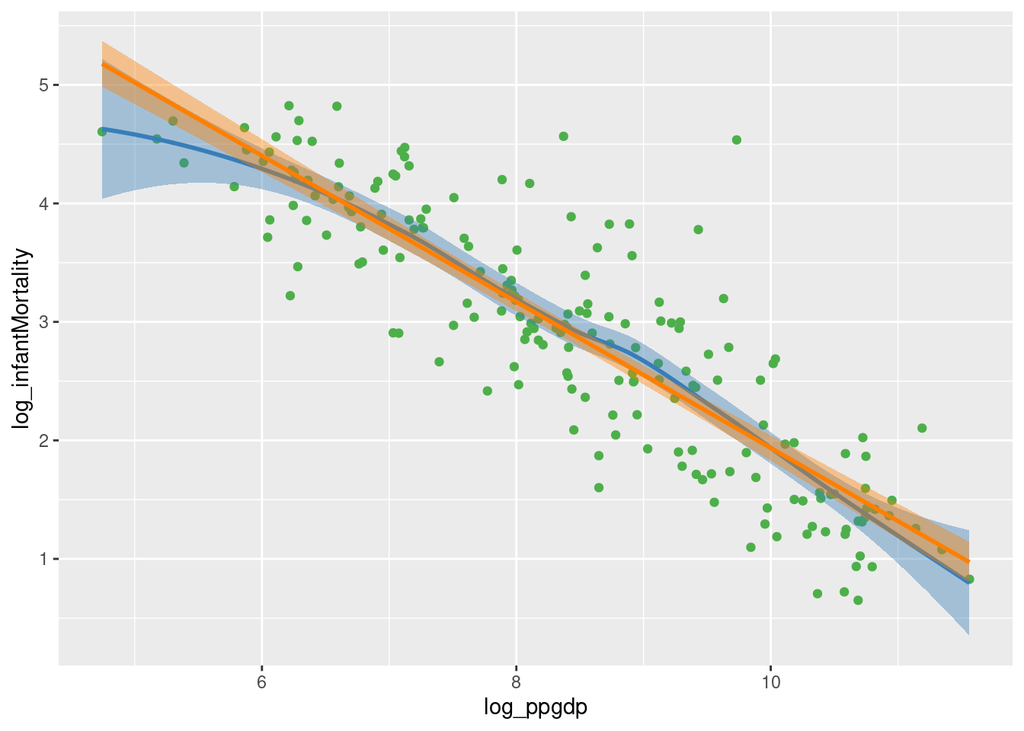

```r
my_cols = brewer.pal(5, "Set1")
UN %>% mutate(log_infantMortality = log(infantMortality),
              log_ppgdp = log(ppgdp)) %>%
  select(log_ppgdp, log_infantMortality) %>%
  na.omit() %>%
  ggplot(aes(x=log_ppgdp, y=log_infantMortality)) +
  geom_point(color=my_cols[3]) +
  geom_smooth(method=loess, fill=my_cols[2], color=my_cols[2]) +
  geom_smooth(method=lm, fill=my_cols[5], color=my_cols[5])
```

Por tanto, si `ppgdp` realmente es una causa de `infantMortality` e incrementamos el PIB per cápita de un país en un 1% hasta $1.01 \times ppgdp$, la mortalidad infantil sería:

$$\exp(\beta_0)(1.01 \times \text{ppgdp})^{\beta_1} \: = \: 1.01^{\beta_1} \times \exp(\beta_0)(\text{ppgdp}^{\beta_1})$$

En este caso, $\beta_1 = -0.617$ por lo que tenemos un cambio respecto a la situación inicial de la variable de salida de $1.01^{-0.617} = 0.994$. Es decir, para un incremento de un 1% en el PIB per cápita de un país, la mortalidad infantil se vería reducida en un 0.6% (ya que el modelo dice que su valor es 99.4% de su valor de partida). Los economistas llaman a este tipo de coeficiente ($\beta_1$) en una regresión log-log un coeficiente de *elasticidad* (Fox and Weisberg 2011).

## 3.2 Transformaciones para igualar escalas

También es bastante común aplicar transformaciones en datos cuantitativos para igualar las escalas de representación de las variables. En muchos modelos, si una de nuestras variables tiene una escala mucho mayor que las demás, sus valores tienden a predominar en los resultados, enmascarando la influencia de las demsá variables.

Por este motivo, en muchos modelos es importante garantizar que todas las variables se representan en escalas comparables, de forma que ninguna predomine sobre el resto. Conviene aclarar un poco algunos términos que se suelen emplear de forma indistinta:

- **Reescalado o cambio de escala**: Consiste en sumar o restar una constante a un vector, y luego multiplicar o dividir por una constante. Por ejemplo, para transformar la unidad de medida de una variable (grados Farenheit $\rightarrow$ grados Celsius).
- **Normalización**: Consiste en dividir por la norma de un vector, por ejemplo para hacer su distancia euclídea igual a 1.
- **Estandarización**: Consiste en restar a un vector una medida de localización o nivel (e.g. media, mediana) y dividir por una medida de escala (dispersión). Por ejemplo, si restamos la media y dividimos por la desviación típica hacemos que la distribución tenga media 0 y desviación típica 1.

Algunas alternativas comunes son:

$$\text{Estandarización} \quad \rightarrow \quad Y = \frac{X-\bar{x}}{s_{x}}$$

$$\text{Escalado min-max} \quad \rightarrow \quad Y = \frac{X-min_{x}}{max_{x} - min_{x}}$$

En R, la función `scale()` se puede utilizar para realizar estas operaciones de estandarización. Automáticamente, puede actuar sobre las columnas de un `data.frame`, aplicando la misma operación a todas ellas (siempre que todas sean cuantitativas).

Por ejemplo, para la operación de *estandarización*:

```r
data(iris)
iris %>%
  mutate_at(vars(-Species), funs(scale(.)))
```

| Sepal.Length | Sepal.Width | Petal.Length | Petal.Width | Species |
| --- | --- | --- | --- | --- |
| -0.89767388 | 1.01560199 | -1.33575163 | -1.3110521482 | setosa |
| -1.13920048 | -0.13153881 | -1.33575163 | -1.3110521482 | setosa |
| -1.38072709 | 0.32731751 | -1.39239929 | -1.3110521482 | setosa |
| -1.50149039 | 0.09788935 | -1.27910398 | -1.3110521482 | setosa |
| -1.01843718 | 1.24503015 | -1.33575163 | -1.3110521482 | setosa |
| -0.53538397 | 1.93331463 | -1.16580868 | -1.0486667950 | setosa |
| -1.50149039 | 0.78617383 | -1.33575163 | -1.1798594716 | setosa |
| -1.01843718 | 0.78617383 | -1.27910398 | -1.3110521482 | setosa |
| -1.74301699 | -0.36096697 | -1.33575163 | -1.3110521482 | setosa |
| -1.13920048 | 0.09788935 | -1.27910398 | -1.4422448248 | setosa |

[output cut: 140 more lines]

Y para el *escalado min-max* tenemos:

```r
iris %>%
  mutate_at(vars(-Species), funs(scale(., center = min(.), scale = max(.) - min(.))))
```

| Sepal.Length | Sepal.Width | Petal.Length | Petal.Width | Species |
| --- | --- | --- | --- | --- |
| 0.22222222 | 0.62500000 | 0.06779661 | 0.04166667 | setosa |
| 0.16666667 | 0.41666667 | 0.06779661 | 0.04166667 | setosa |
| 0.11111111 | 0.50000000 | 0.05084746 | 0.04166667 | setosa |
| 0.08333333 | 0.45833333 | 0.08474576 | 0.04166667 | setosa |
| 0.19444444 | 0.66666667 | 0.06779661 | 0.04166667 | setosa |
| 0.30555556 | 0.79166667 | 0.11864407 | 0.12500000 | setosa |
| 0.08333333 | 0.58333333 | 0.06779661 | 0.08333333 | setosa |
| 0.19444444 | 0.58333333 | 0.08474576 | 0.04166667 | setosa |
| 0.02777778 | 0.37500000 | 0.06779661 | 0.04166667 | setosa |
| 0.16666667 | 0.45833333 | 0.08474576 | 0.00000000 | setosa |

[output cut: 140 more lines]

## 3.3 Variables con rango restringido

Cuando nuestras variables tienen un rango restringido de valores, por ejemplo en el intervalo $[0, 1]$ (proporciones, porcentajes, etc.) debemos incluir esta restricción a la hora de considerar las transformaciones más adecuadas para nuestros datos.

En la literatura se pueden encontrar algunos ejemplos de transformaciones para este tipo de datos (Fox and Weisberg 2011):

1. La transformación arcoseno raíz cuadrada: $T_{asinsqrt}(x) = sin^{-1}(\sqrt{x})$.
2. La transformación *logit* o *log-odds*: $T_{logit}(x) = \text{logit}(x) = log_e(\frac{x}{1-x})$.

# 4 Procesado de variables categóricas

Cuando las variables de nuestro modelo de regresión son **cualitativas** en lugar de cuantitativas (como en la mayoría de ejemplos vistos hasta el momento), es necesario utilizar una estrategia específica para incluirlas en el sistema.

Las situaciones más típicas son:

- Variables **dicotómicas**: con dos posibles categorías. Ej: hombre/mujer.
- Variables **politómicas**: con más de dos categorías. Ej: país de origen.
- Variables **ordinales** o de **ranking**: existe una ordenación entre las categorías. Ejs: titulación académica de mayor rango obtenida, nivel de satisfacción (bueno, regular, malo).

En R, las variables categóricas se denominan **factores** (*factors*) y sus categorías **niveles** (*levels*). Es importante procesarlos adecuadamente para que los modelos aprovechen la información que contienen estas variables. Por otro lado, si se codifica incorrectamente esta información los modelos pueden estar realizando operaciones absurdas aunque nos devuelvan resultados aparentemente válidos.

En esta sección vamos a presentar simplemente algunas operaciones básicas para preparación y representación de datos categóricos. En el Tema 3 veremos con más detalle técnicas adicionales, así como métodos de representación gráfica cuando aparecen este tipo de variables.

## 4.1 El paquete `forcats`

Dentro del ecosistema de paquetes `tidyverse` en R, [el paquete `forcats`](https://forcats.tidyverse.org/index.html) está dedicado al tratamiento de datos categóricos. Aunque la [lista completa de funciones](https://forcats.tidyverse.org/reference/index.html) que incluye es más extensa, algunas de las más habituales son:

- `fct_reorder()`: Reordenación de valores de un factor usando otra variable.
- `fct_infreq()`: Reordenación de valores de un factor por su frencuencia de aparición.
- `fct_relevel()`: Cambiar manualmente la ordenación de un factor (especificando el nuevo orden).
- `fct_lump()`: Agrupar los valores más/menos frecuentes en una categoría global `"otros"`.

Sin embargo, todas las funciones de este paquete dan por supuesto que los valores codificados en la tabla de datos original son correctos. En muchos casos esto no es cierto, y primero debemos arreglar manualmente (o usando programas especializados) los valores incorrectos que hayamos detectado en un EDA previo. El documento `2.A` de este tema presenta un análisis completo de los datos de **ACME Telephone**, que ilustra una situación de este tipo para las variables categóricas `regionType`, `marriageStatus` y `creditCard`.

## 4.2 Lectura de datos categóricos

El documento `2.A` de este tema muestra un análisis completo de los datos del caso *ACME Telephone*. En dicho proceso, vemos que las variables cualitativas se convierten explícitamente en factores mediante el código siguiente:

```r
ACMETelephoneABT$regionType = factor(ACMETelephoneABT$regionType)
ACMETelephoneABT$marriageStatus = factor(ACMETelephoneABT$marriageStatus)
ACMETelephoneABT$creditCard = factor(ACMETelephoneABT$creditCard)
```

```r
default.stringsAsFactors()
```

```
## [1] FALSE
```

Sin embargo, este comportamiento de transformar `strings` a factores [puede que no sea siempre el más adecuado](http://simplystatistics.org/2015/07/24/stringsasfactors-an-unauthorized-biography/). Además, por defecto, R **ordena los niveles de los factores alfabéticamente**, según sus etiquetas. Debemos tener cuidado con esto, puesto que en muchos análisis **es muy importante** saber **qué nivel se está tomando como referencia**, de entre los valores posibles de un factor, para comparar con los restantes.

En ciertos modelos, la elección como referencia de uno de los valores del factor (típicamente el primero que aparece en la lista de niveles) cambia por completo los resultados, así como la interpretación de los mismos.

Además, en variables ordinales se debe respetar estrictamente el orden preestablecido de los niveles. Por ejemplo, una ordenación `("regular" < "bueno" < "malo")` es inaceptable. Para establecer una ordenación explícita entre los niveles hay que especificarla manualmente si no coincide con la alfabética, y además configurar el argumento `ordered = TRUE` en la función `factor()`:

```r
satisfaccion <- rep(c("malo", "bueno", "regular"), c(3,3,3))
satisfaccion <- factor(satisfaccion, ordered = TRUE, levels = c("malo", "regular", "bueno"))
satisfaccion
```

```
## [1] malo    malo    malo    bueno   bueno   bueno   regular regular regular
## Levels: malo < regular < bueno
```

Por ejemplo, para comprobar qué nivel se toma como referencia en cada uno de los factores de la tabla `ACMETelephoneABT` usamos la funión `levels()`:

```r
levels(ACMETelephoneABT$creditCard)
```

```
## [1] " false" " true"
```

```r
levels(ACMETelephoneABT$regionType)
```

```
## [1] " rural"    " suburban" " town"
```

```r
levels(ACMETelephoneABT$marriageStatus)
```

```
## [1] " no"  " yes"
```

## 4.3 Reordenación de niveles

Si queremos recolocar los niveles podemos hacerlo de la siguiente forma:

```r
reorder_marriage = factor(ACMETelephoneABT$marriageStatus, levels=(c(' yes', ' no', ' unknown')))
levels(reorder_marriage)
```

```
## [1] " yes"     " no"      " unknown"
```

Cuando leemos niveles ordinales, normalmente se representan mediante un ranking numérico. En ese caso, R los interpreta normalmente como vector numérico y no como factor (solo se plantea conversión automática con `strings`).

```r
# Ejemplo con datos ad-hoc
drug = data.frame(dosage=c(1,1,2,1,4,4,2,4,8,8,8,4,8,1))
class(drug$dosage)
```

```
## [1] "numeric"
```

```r
drug$dosage = factor(drug$dosage, levels = c("8", "4", "2", "1"), labels = c("D8", "D4", "D2", "D1"))
levels(drug$dosage)
```

```
## [1] "D8" "D4" "D2" "D1"
```

Alternativamente, se puede usar alguna de las funciones incluidas en el paquete `forcats` para reordenación de niveles, especialmente si nuestras instrucciones forman parte de una secuencia conectada mediante pipes (`%>%`) en `tidyverse`.

## 4.4 Contrastes entre niveles de un factor

Al introducir un factor en un modelo de regresión, R crea automáticamente una serie de variables numéricas para tener en cuenta dicho factor en el modelo. Esas variables se denominan **contrastes** y existen varios métodos para generarlas.

El método más extendido, y la opción por defecto en R, es aplicar la función `contr.treatment`. Esta función actúa de la siguiente forma:

- Consideremos un factor con $m$ niveles.
- Se toma siempre como **nivel de referencia** el primer nivel que aparece en la lista de posibles valores que toma la variable (e.g. que devuelve la función `levels()`).
- Entonces, `contr.treatment` genera `m-1` variables que se denominan **ficticias** (en inglés *dummy variables*).
- Para cada caso en el que nuestra variable toma como valor la categoría de referencia, se ponen todas las `m-1` variables ficticias a cero en dicho caso (fila).
- Para el resto de casos, se pone a 1 la variable ficticia que corresponde con el valor de la variable categórica en ese caso, y el resto de variables ficticias se dejan a 0.

Este no es el único procedimiento que podemos emplear para representar variables categóricas en nuestros modelos, sino que existen muchas otras alternativas (Fox and Weisberg 2011; Faraway 2016). Más adelante, en el Tema 3, veremos otras variantes.

## 4.5 Variables ficticias (matriz del modelo)

Cuando creamos un modelo con variables ficticias es importante entender qué aproximación estamos proponiendo y cómo interpretar los resultados obtenidos. Supongamos un conjunto de datos sintético, con una variable de salida `y`, cuantitativa, y dos variables de entrada: una cuantitativa, `x` y otra categórica, `fac`. La variable `fac` tiene cuatro posibles valores: `norte`, `sur`, `este` y `oeste`.

Los datos se presentan en la siguiente tabla.

```r
x = rnorm(50, mean=5, sd=2)
fac = factor(rep(c('norte', 'sur', 'este', 'oeste'), c(13,19,10,8)))
group_means = rep(c(12,20,8,1), c(13,19,10,8))
jitter= rnorm(50, mean=5, sd=0.4)
y = (3 * x) + jitter + group_means


my_set = tibble(x = x, fac = fac, y = y)
sample_n(my_set, 10)
```

| x | fac | y |
| --- | --- | --- |
| 7.1715609 | sur | 46.38374 |
| 3.3264968 | norte | 27.24620 |
| -0.2525541 | sur | 24.33495 |
| 5.7042310 | norte | 34.20017 |
| 6.1935035 | norte | 36.14067 |
| 3.7849816 | norte | 27.77692 |
| 5.4708911 | este | 29.14646 |
| 2.3511152 | este | 20.06762 |
| 2.3473981 | sur | 32.11907 |
| 2.0238595 | norte | 23.52805 |

La representación gráfica de la variable `y` contra `x`, en función de cada una de las cuatro regiones es:

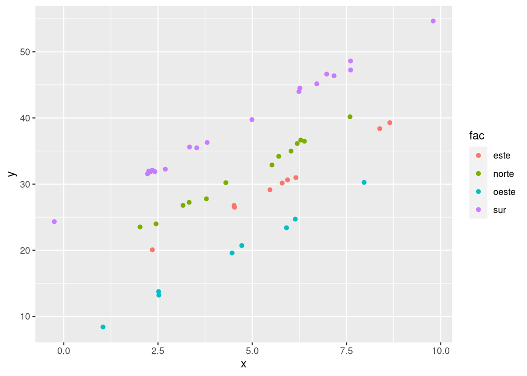

Figure 4.1: Representación gráfica de los puntos de nuestros datos sintéticos para el ejemplo de variables ficticias.

```r
my_set %>%
  ggplot(aes(y=y, x=x, colour=fac)) +
  geom_point()
```

Al codificar nuestra variable categórica mediante **variables ficticias** (*dummy coding*), lo que hacemos es crear tres variables binarias que sustituyen en el modelo a la variable categórica original. La llamada `levels(fac)` nos devuelve la lista de posibles niveles de ese factor. Como `este` es el primer nivel que aparece, se toma como nivel de referencia. Las tres variables ficticias que se crean son `facnorte`, `facoeste` y `facsur`. Todos los casos en los que `fac="este"` tendrán esas tres variables a 0. Para el resto de casos, se pone a 1 la variable que coincide con el valor de `fac` en ese caso y el resto se dejan a 0. Por ejemplo, en todos los casos en los que `fac="norte"` la variable `facnorte` vale 1 y el resto 0.

Podemos comprobar fácilmente el valor asignado en cada fila a nuestras variables ficticias inspeccionando la matriz del modelo, que generamos con la función `model.matrix()` de R. Se usa la fórmula `~ x + fac`, estándar de R, porque como hemos dicho esta forma de codificar es la aplicada por defecto al crear modelos que involucran factores.

```r
levels(fac)
```

```
## [1] "este"  "norte" "oeste" "sur"
```

```r
as_tibble(model.matrix(~ x + fac))
```

| (Intercept) | x | facnorte | facoeste | facsur |
| --- | --- | --- | --- | --- |
| 1 | 5.7042310 | 1 | 0 | 0 |
| 1 | 6.0301862 | 1 | 0 | 0 |
| 1 | 7.5952212 | 1 | 0 | 0 |
| 1 | 3.7849816 | 1 | 0 | 0 |
| 1 | 2.0238595 | 1 | 0 | 0 |
| 1 | 6.3848431 | 1 | 0 | 0 |
| 1 | 6.2881541 | 1 | 0 | 0 |
| 1 | 3.1640840 | 1 | 0 | 0 |
| 1 | 5.5246733 | 1 | 0 | 0 |
| 1 | 3.3264968 | 1 | 0 | 0 |

[output cut: 40 more lines]

Si, por ejemplo, queremos ajustar un modelo de regresión a estos datos, tenemos:

$$y = \beta_0 + \beta_1 x + \beta_{norte}facnorte + \beta_{oeste}facoeste + \beta_{sur}facsur$$

En código de R, usando la función estándar `lm()`, tan solo escribimos la fórmula simple `y ~ x + fac`, puesto que el programa se encarga internamente de hacer *dummy coding*.

```r
model_dummy = lm(y ~ x + fac)
summary(model_dummy)
```

```
##
## Call:
## lm(formula = y ~ x + fac)
##
## Residuals:
##     Min      1Q  Median      3Q     Max
## -0.8599 -0.2565  0.1013  0.2484  0.6056
##
## Coefficients:
##             Estimate Std. Error t value Pr(>|t|)
## (Intercept) 12.64262    0.19148   66.03   <2e-16 ***
## x            3.05712    0.02591  118.00   <2e-16 ***
## facnorte     4.22003    0.16625   25.38   <2e-16 ***
## facoeste    -6.86912    0.18868  -36.41   <2e-16 ***
## facsur      12.15637    0.15537   78.24   <2e-16 ***
## ---
## Signif. codes:  0 '***' 0.001 '**' 0.01 '*' 0.05 '.' 0.1 ' ' 1
##
## Residual standard error: 0.3921 on 45 degrees of freedom
## Multiple R-squared:  0.9984, Adjusted R-squared:  0.9983
## F-statistic:  7168 on 4 and 45 DF,  p-value: < 2.2e-16
```

Gráficamente, el modelo que estamos proponiendo es el siguiente:

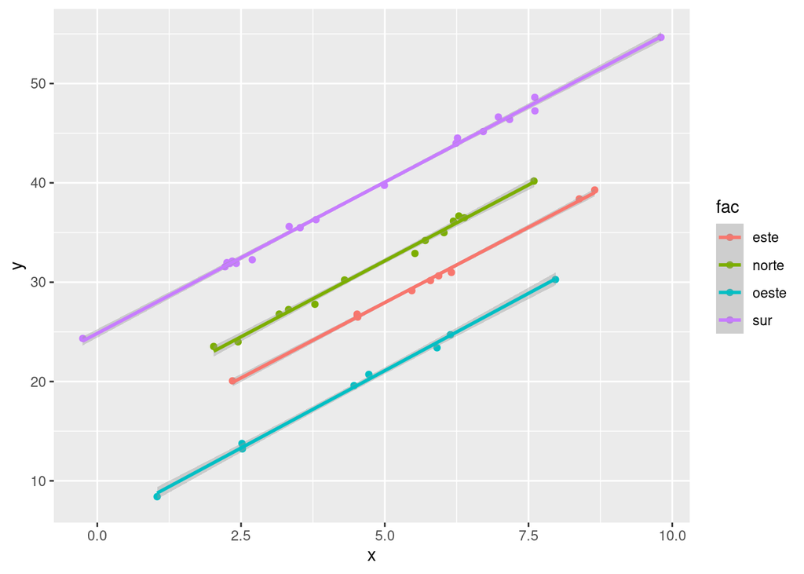

```r
my_set %>%
  ggplot(aes(x=x, y=y, color=fac, group=fac)) +
  geom_point() +
  geom_smooth(method = "lm")
```

Por ejemplo, para el grupo de referencia de los casos con `fac="este"` la recta de regresión que propone este modelo es:

$$y = \beta_0 + \beta_1 x; \quad facnorte = facoeste = facsur = 0.$$

Y para el caso del grupo de casos en los que `fac="norte"`, la recta es:

$$y = \beta_0 + \beta_1 x + \beta_{norte}; \quad facnorte = 1; \; facoeste = facsur = 0.$$

Analogamente, podemos obtener de forma sencilla la recta propuesta para los otros dos grupos.

## 4.6 Referencias adicionales

El documento `2.B-Variables dummy` de este tema incluye abundante información adicional sobre diferentes estrategias de codificación de valores categóricos para su inclusion en modelos de análisis de datos.

Además, se pueden consultar otras fuentes de información:

- La documentación de `forcats` incluye un [documento introductorio](https://forcats.tidyverse.org/articles/forcats.html) para ilustrar los usos básicos de algunas funciones incluidas en este paquete.
- El capítulo 15 (versión online) de Wickham y Grolemund (2016) contiene una descripción detallada del uso de `forcats` para procesar datos categóricos en `tidyverse`.

# 5 Portabilidad de tipos de datos

En muchas ocasiones, el flujo de trabajo de preparación de datos nos enfrenta a situaciones en las que hay que realizar una **portabilidad de tipos de datos**, es decir, cambiar el tipo de representación de información de una variable a otro tipo más conveniente.

La siguiente tabla, tomada de Aggarwal (2015), resume los principales tipos de portabilidades de datos que se suelen considerar en esta fase:

| Tipo_origen | Tipo_destino | Método |
| --- | --- | --- |
| Numérico | Categórico | Discretización, binarización, *binning*, *quantization* |
| Categórico | Numérico | Binarización (variables binarias) |
| Texto | Numérico | Latent Semantic Analysis (LSA) |
| Serie temporal | Secuencia discreta | Symbolic Aggregate approXimation (SAX) |
| Serie temporal | Numérico multidimensional | Discrete Wavelet Transform (DWT), Discrete Fourier Transform (DFT) |
| Secuencia discreta | Numérico multidimensional | DWT, DFT |
| Espacial | Numérico multidimensional | 2D DWT, DFT |
| Grafo | Numérico multidimensional | Multi-Dimensional Scaling (MDS), espectral |
| Cualquier tipo | Grafo | Grafo de similaridad |

De entre las portabilidades básicas más habituales, podemos resaltar el paso de datos cuantitativos (numéricos) a datos cualitativos (categóricos) y viceversa.

## 5.1 Dato cuantiativo a cualitativo: discretización

Un caso habitual es transformar una variable cuantitativa en una categórica. Esto se consigue definiendo una serie de intervalos y **asignando los valores originales al intervalo correspondiente**. De esta forma, acabamos con una variable categórica con tantas categorías como intervalos hayamos definido.

**Importante**: en inglés se usan varios términos alternativos para identificar esta operación:

- *Discretization*, más habitual en documentos académicos y libros de texto, como (Aggarwal 2015).
- *Binning*, más común en blogs, documentación técnica, etc. Viene de agrupar los valores en *bins*, los intervalos usados en un histograma para representar las barras. Es importante no confundirlo con *binarization*, la operación para representar un dato cualitativo con variables binarias (o una variable cuantitativa a valores binarios {0, 1}).

Un factor de diseño importante en esta operación es determinar el número de intervalos definidos y su rango. Existen varias alternativas:

1. **Ancho fijo**: Cada intervalo $[a, b]$ se define de forma que su amplitud $(b-a)$ sea la misma para todos los intervalos. Debemos tener mucho cuidado si la **distribución de valores no es uniforme**, puesto que el número de puntos que caerá dentro de cada intervalo puede ser muy diferente. Esto puede perjudicar o falsear seriamente los resultados de nuestro análisis.
2. **Ancho fijo (log)**: Cada intervalo $[a, b]$ se define de forma que su amplitud en escala logarítmica $log(b) - log(a)$ tiene el mismo valor. Esta variante incluye una transformación de los datos cuando la distribución tiene mucha dispersión (cola larga).
3. **Discretización por cuantiles**: La amplitud de cada intervalo se define de forma que, aproximadamente, todos contengan el mismo número de muestras. La desventaja de esta aproximación es que los límites de los diferentes intervalos pueden ser muy dispares, y dificultar la interpretación.

En muchos casos, la decisión de discretizar una variable cuantitativa proviene de conocimiento teórico previo en el área de aplicación. Sin embargo, podemos encontrar muchos autores que alertan **en contra de discretizar variables cuantitativas** de forma habitual (Harrell 2015; Osborne 2012). Las principales razones son:

- Se pierde información en el proceso (como en muchos otros casos de portabilidad de datos).
- Los resultados del modelo pueden ser engañosos o imprecisos, por ejemplo si al discretizar tenemos grupos con muchos datos y otros con muy pocos datos.
- No podemos observar la evolución del “efecto” de la variable cuantitativa sobre la salida, a lo largo de todo su rango de valores. Esto es ahora relativamente sencillo de representar gráficamente, incluso para variables transformadas, con el paquete `effects`.

En el nuevo libro de Kuhn y Johnson sobre *feature engineering*, los autores describen de forma excelente un [caso de estudio](http://www.feat.engineering/engineering-numeric-predictors.html#binning) sobre discretización de variables continuas. Ese ejemplo demuestra mucho de los problemas que pueden surgir, asociados a este procedimiento.

En R, la discretización de variables cuantitativas se implementa, entre otras alternativas, mediante la función `cut()` de R base o la función `cut2()` del paquete`Hmisc` (Torgo 2016; Harrell 2015).

Veamos un ejemplo con la variable `age` del dataset `faraway::pima`. Si queremos crear 5 intervalos, todos ellos con la misma longitud, usamos la función `cut()`:

```r
summary(pima$age)
```

```
##    Min. 1st Qu.  Median    Mean 3rd Qu.    Max.
##   21.00   24.00   29.00   33.24   41.00   81.00
```

```r
pima %>%
  mutate(newage = cut(age, 5)) %>%
  select(newage) %>%
  table()
```

```
## .
## (20.9,33]   (33,45]   (45,57]   (57,69] (69,81.1]
##       474       176        76        39         3
```

También se pueden poner nuevas etiquetas a los intervalos creados:

```r
pima %>%
  mutate(newage = cut(age, 5,
                      labels = c("joven", "mediana edad", "veterana",
                                 "mayor", "muy mayor"))) %>%
  select(newage) %>%
  table()
```

```
## .
##        joven mediana edad     veterana        mayor    muy mayor
##          474          176           76           39            3
```

Aquí se hace patente el problema del desequilibrio en el número de casos que se asignan a cada intervalo. Otra opción es utilizar la función `Hmisc::cut2()` para hacer interavlos que contenga aproximadamente la misma frecuencia de casos. Sin embargo, si queremos definir nuestras propias etiquetas para cada intervalo con esta función debemos hacerlo aparte:

```r
summary(pima$age)
```

```
##    Min. 1st Qu.  Median    Mean 3rd Qu.    Max.
##   21.00   24.00   29.00   33.24   41.00   81.00
```

```r
pima %>%
  mutate(newage = factor(cut2(age, g=5))) %>%
  select(newage) %>%
  table()
```

```
## .
## [21,24) [24,28) [28,34) [34,44) [44,81]
##     173     159     142     153     141
```

```r
pima %>%
  mutate(newage = factor(cut2(age, g=5),
                         labels = c("menos24", "menos28", "menos34",
                                    "menos44", "44 a 81"))) %>%
  select(newage) %>%
  table()
```

```
## .
## menos24 menos28 menos34 menos44 44 a 81
##     173     159     142     153     141
```

## 5.2 Dato cuantitativo a binario: binarización

Un caso particular de portabilidad de datos cuantitativos a cualitativos es la binarización, en inglés *binarization* (Zheng and Casari 2018). Este proceso suele ser más útil y efectivo en modelos de predicción que en explicativos.

Un ejemplo sería la construcción de un sistema de recomendación a partir de los datos del [Echo Nest Taste Profile Dataset](https://labrosa.ee.columbia.edu/millionsong/tasteprofile). Este conjunto de datos, referenciado en el capítulo 2 de (Zheng and Casari 2018), contiene más de 48 millones de entradas que relacionan en forma de tripletas `(ID_usuario, ID_cancion, num_reprod)` el número de veces que una canción ha sido reproducida por un usuario individual.

Si queremos usar esta información para recomendar canciones a otros usuarios nos encontramos con el problema de que un grupo pequeño de canciones (1%) acumula miles de reproducciones, mientras que el 99% de las canciones restantes tienen menos de 24 reproducciones. Si intentamos aplicar cualquier algoritmo de predicción sobre estos datos, los valores de reproducciones excesivamente grandes de ese 1% de canciones prevalecerán sobre el resto.

Una solución para un sistema predictivo es sustituir el valor real de reproducciones por una variable binaria que tome valores $\{0, 1\}$. Es decir, la variable vale $1$ si el usuario ha escuchado alguna vez esa canción y $0$ en caso contrario. Con esta sencilla operación, y suponiendo que el número de canciones que escucha un usuario es limitado (por lo que la matriz de recomendación será *dispersa*), esta representación resulta más **robusta** para detectar gustos comunes entre los usuarios.

## 5.3 Dato cualitativo a cuantiativo: variables binarias

Como ya hemos visto, los datos cualitativos no se pueden utilizar directamente en muchos modelos y algoritmos, por lo que primero debemos representarlos numéricamente siguiendo alguna estrategia. Normalmente, la estrategia escogida determina el tipo de aproximación que está proponiendo nuestro modelo para explicar los datos.

Un ejemplo sería la utilización de variables binarias (*dummy variables*) para incluir variables categóricas en un modelo de regresión. En el Tema 3 presentamos más alternativas de codificación de variables categóricas usando estrategias similares.

# 6 Detección e imputación de datos faltantes

Es frecuente encontrarnos con valores desconocidos en muchos conjuntos de datos reales. Las causas que provocan la ausencia de datos pueden ser diversas: desde errores de medida hasta problemas o roturas de instrumentos, pasando por razones más específicas (como tendencia de algunas personas con ciertas características a no responder a algunas preguntas sobre temas sensibles). A estos valores desconocidos se les denomina **datos faltantes** (en inglés *missing data*).

Los valores faltantes se representan de forma estándar en R mediante el valor especial `NA` (nótese que no va rodeado de comillas). Estas siglas indican *not available*, es decir, que el valor del dato en esa posición no está disponible.

Los datos faltantes pueden dificultar mucho algunos análisis. Por ejemplo, determinados algoritmos de aprendizaje máquina como SVM, redes neuronales o muchos modelos lineales no toleran en absoluto la presencia de datos faltantes. Sin embargo, otros algoritmos como los árboles de clasificación (CART) sí cuentan con implementaciones que pueden admitir la presencia de datos faltantes.

En general, existen múltiples herramientas y estrategias para poder deducir qué valor se podría asignar a esos casos desconocidos. El proceso que asigna valores a los datos para los cuales se desconoce su valor real se denomina **imputación de datos** (en inglés *data imputation*).

El primer problema con el que nos podemos encontrar es cómo están codificados los valores faltantes. En algunas ocasiones, se ha tenido la precaución de codificar estos valores correctamente usando el símbolo `NA`. Pero en muchos otros casos, se han usado valores distintos por ejemplo:

- Valores imposibles para una variable. Por ejemplo, `-1` o `-1000` para una variable positiva.
- Fechas imposibles para datos temporales. Por ejemplo `1 enero de 1900` para datos que deberían partir del año 1950 en adelante.
- Otros símbolos diversos, como `?`, `Unknown`, `Unk`, etc.

Son especialmente peligrosos aquellos casos en los que alguien o algún sistema decide usar un valor aparentemente válido para codificar un dato faltante. Por ejemplo `0` para un dato cuantitativo, `FALSE` para una variable lógica binaria o una fecha particular para un dato de fecha. Un dato faltante tampoco se debe codificar como `void`, `null`, `None` o cualquier otra variante que en computación identifique a un espacio de memoria vacío. La Figura 6.1 muestra de forma muy clara la diferencia entre un valor cero, una posición de memoria vacía y un dato faltante.

La única excepción son las bases de datos relacionales, en donde la única forma que tenemos de codificar un dato faltante en una celda suele ser mediante el valor `NULL`. Al definir el esquema de una tabla de datos, tendremos que indicar explícitamente si en uno de los campos pueden existir datos faltantes o no.

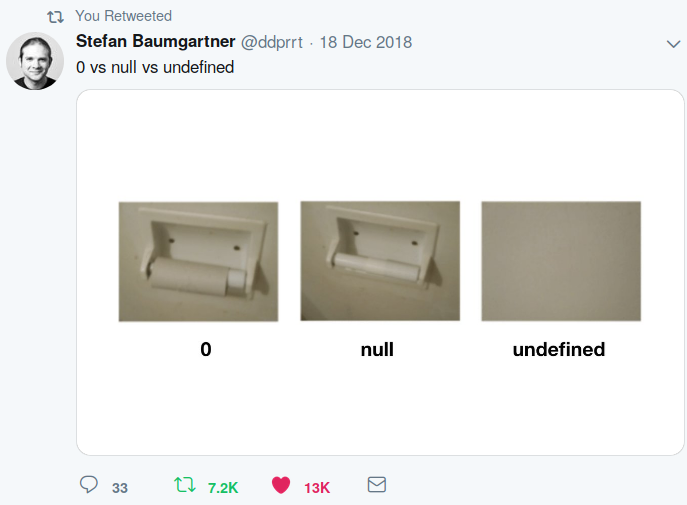

Figure 6.1: 0 vs null vs undefined: Fuente: [Twitter, S. Baumgartner (dic. 2018)](https://twitter.com/ddprrt/status/1074955395528040448)

## 6.1 Algunos consejos para trabajo con datos faltantes

En la sección 3.10 de (Harrell 2015), podemos encontrar algunos consejos muy generales sobre cómo afrontar el tratamiento de datos faltantes. Un paso previo imprescindible es identificar en nuestro conjunto de datos la **proporción de casos con algún valor faltante**, que vamos a denotar como $f$.

Los casos a considerar son:

- Si $f < 0.03$: El problema no es grave, y se pueden utilizar sin demasiado riesgo técnicas sencillas de imputación de datos, por ejemplo:
  - Asignar a una variable cuantitativa la mediana del resto de sus valores conocidos.
  - Asignar a una variable categórica la categoría más frecuente del resto de sus valores conocidos.
  - También se pueden descartar los casos con valores faltantes usando `complete.cases()`.
- Si $f \geq 0.03$ Podemos utilizar imputación múltiple o alguna técnica de imputación que explore correlaciones o similaridades entre los casos. También sería conveniente modificar todas las fórmulas de ajuste y evaluación del modelo (e.g. en modelos lineales) para tener en cuenta los efectos de la imputación. Por ejemplo, la función `rms::fit.mult.impute()` automatiza estos ajustes.
- Si hay múltiples variables con valores faltantes frecuentes se necesitará repetir el proceso de imputación varias veces, intentando realizar un “análisis de sensibiliad” para determinar si nuestro sistema de imputación está introduciendo sesgo en los datos.

Hay un gran número de paquetes en R que permiten imputación de datos faltantes, implementando a veces técnicas muy sofisticadas (a costa de elevados tiempos de cómputo y grandes requisitos de memoria y capacidad de procesado). Entre ellos cabe destacar `mice`, `Amelia`, `Hmisc` con su función `aregImpute`, las funciones del paquete `DMwR2` para imputación y comprobación, `imputeR`, `simputation`, etc. Destaca también `VIM` (Visualizaton and Imputation of Missing Values), por incluir potentes herramientas gráficas para detección de patrones en la aparición de datos faltantes en nuestros datasets.

# 7 Comprobación de reglas de datos

Otro aspecto muy importante en la preparación de datos es la validación de los rangos de valores y categorías específicas que toman nuestras variables. De esta forma podemos detectar múltiples problemas de inconsistencias (diferentes representaciones del mismo valor), errores en la introducción de datos, en el volcado de valores desde otros sistemas de información, etc.

En R, los paquetes `validate` y `validatetools` implementan funciones y una sintaxis que permite automatizar de forma sencilla y conveniente las tareas de validación. Entre otras funciones, estos paquetes permiten:

- Comprobar nuestros datasets pasando reglas predefinidas, bien dentro del mismo dataset o dependientes de otros datasets.
- Importar y exportar conjuntos de reglas de archivos estructurados o sin formato.
- Visualizar e inspeccionar los resultados de un paso de validación.
- Realizar tareas básicas de mantenimiento de reglas.
- Definir y mantener indicadores de calidad de datos, independientes del dataset.

La [viñeta de introducción a `validate`](https://cran.r-project.org/web/packages/validate/vignettes/introduction.html) introduce muchas de estas funciones con ejemplos fáciles de replicar.

# 8 Referencias adicionales

En general, no existen muchas referencias que reúnan en un solo volumen información diversa sobre todas las técnicas que hemos visto aquí, y sobre las que se introducirán en el documento `2.2 - Feature Engineering`, dentro de este mismo tema.

Durante muchos años, una de las pocas referencias sobre limpieza y preparación de datos verdaderamente amplia fue (Pyle 1999). Aunque ya algo desfasado en muchos aspectos técnicos, todavía reúne un buen número de consejos y estrategias generales que han ido apareciendo de nuevo en otras fuentes.

Entre las referencias posteriores, cabe destacar el resumen completo incluido en (Torgo 2016), así como el extenso tratamiento sobre datos faltantes y transformaciones de variables en el contexto de modelos lineales de Harrell (2015). También se encuentran algunos apuntes interesantes en el primer libro de Kuhn y Johnson (2013). Ambos autores preparan [un nuevo volumen](http://www.feat.engineering/) exclusivamente dedicado a todos los aspectos de *feature engineering*. Fox y Wesiberg (2011) tratan de forma detallada muchos aspectos de transformación de variables, incluyendo una discusión y ejemplos paso a paso de cómo representar los efectos de las variables transformadas mediante el paquete `effects`, así como la manera de reportar los resultados deshaciendo las transformaciones aplicadas a las variables de nuestro modelo.

En Python, una completa referencia ha sido publicada recientemente (Zheng and Casari 2018). Cabe destacar también (Buuren 2018) como la mejor y más completa referencia práctica sobre tratamiento de datos faltantes que existe en la actualidad. El autor lo es también del paquete R `mice`. La versión electrónica del libro está disponible de forma gratuita (https://stefvanbuuren.name/fimd/).

Es destacable también la obra enciclopédica sobre técnicas de *data mining* de Aggarwal (2015). El capítulo 2 explica con detalle muchas de las técnicas que hemos visto aquí de forma sistemática (y un tanto “académica”), con muchas referencias externas. Finalmente, también merece atención (Maydanchik 2007), que expone de manera sistemática y efectiva cómo elaborar estrategias de evaluación de calidad de los datos, y producir reglas de validación y control.

# 9 Bibliografía y referencias

Aggarwal, Charu C. 2015. *Data Mining: The Textbook*. Springer.

Buuren, Stef van. 2018. *Flexible Imputation of Missing Data, Second Edition*. CRC Press.

Faraway, Julian J. 2016. *Linear Models with r*. Chapman; Hall/CRC.

Fox, John, and Sanford Weisberg. 2011. *An R Companion to Applied Regression*. 2nd ed. Sage Publishing.

Harrell, F. E. 2015. *Regression Modeling Strategies: With Applications to Linear Models, Logistic and Ordinal Regression, and Survival Analysis*. Springer Series in Statistics. Springer International Publishing. https://books.google.es/books?id=94RgCgAAQBAJ.

Kelleher, John D., Brian Mac Namee, and Aoife D’Arcy. 2015. *Fundamentals of Machine Learning for Predictive Data Analytics: Algorithms, Worked Examples, and Case Studies*. Cambridge, Massachusetts: MIT Press Ltd.

Kuhn, Max, and Kjell Johnson. 2013. *Applied Predictive Modeling*. Springer Science & Business Media.

Maydanchik, Arkady. 2007. *Data Quality Assessment*. Technics Publications.

Osborne, J. W. 2012. *Best Practices in Data Cleaning: A Complete Guide to Everything You Need to Do Before and After Collecting Your Data*. SAGE Publications. https://books.google.es/books?id=bzkXBAAAQBAJ.

Pyle, Dorian. 1999. *Data Preparation for Data Mining*. Morgan Kaufmann.

Torgo, L. 2016. *Data Mining with R: Learning with Case Studies, Second Edition*. Chapman & Hall/CRC Data Mining and Knowledge Discovery Series. CRC Press. https://books.google.es/books?id=2aedDQAAQBAJ.

Wickham, Hadley, and Garrett Grolemund. 2016. *R for Data Science: Import, Tidy, Transform, Visualize, and Model Data*. " O’Reilly Media, Inc.". https://r4ds.had.co.nz.

Zheng, A., and A. Casari. 2018. *Feature Engineering for Machine Learning: Principles and Techniques for Data Scientists*. O’Reilly Media. https://books.google.es/books?id=sthSDwAAQBAJ.

———. 2018. *Feature Engineering for Machine Learning: Principles and Techniques for Data Scientists*. O’Reilly Media. https://books.google.es/books?id=sthSDwAAQBAJ.